# Python_CodeExample

This notebook walks through an implementation of multi-class classification using handwritten digits and a few experiments. The data file is split into training/test sets with 4000/1000 examples respectively.

```python
%matplotlib inline
%reload_ext autoreload
%autoreload 2

import numpy as np
import matplotlib.pyplot as plt
import scipy.io

data = scipy.io.loadmat('digits-py.mat')

X_train = data['X_train']
y_train = data['y_train'].ravel()
X_test  = data['X_test']
y_test  = data['y_test'].ravel()
```

Visualize a loaded example

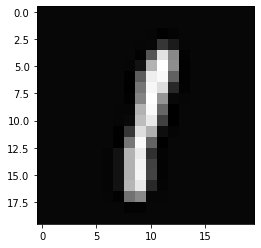

```python
plt.imshow(X_train[99].reshape(20,20), cmap='gray')
```

Below are our functions utilized to train and predict a one vs all classification

```python
def train_one_vs_all(X, y, num_classes, lambda_val):
  # Train a one vs. all logistic regression

  m, n = X.shape

  weight_vectors = np.empty((n,num_classes))
  intercepts = np.empty(num_classes)

  y_c = np.zeros((m,num_classes), dtype = int)
  for i,j in enumerate(y):
    y_c[i][j] = 1

  for c in range(0, num_classes):
    weight_vectors[:,c], intercepts[c] = train_logistic_regression(X, y_c[:,c], lambda_val)

  return weight_vectors, intercepts

def predict_one_vs_all(X, weight_vectors, intercepts):

  pred = np.dot(X, weight_vectors)+intercepts
  predictions = np.argmax(pred, axis = 1)

  return predictions

def train_logistic_regression(X, y, lambda_val):
  from sklearn import linear_model
  import warnings
  model = linear_model.LogisticRegression(C=2./lambda_val, solver='lbfgs')

  # call model.fit(X, y) while suppressing warnings about convergence
  with warnings.catch_warnings():
      warnings.simplefilter("ignore")
      model.fit(X, y)

  weight_vector = model.coef_.ravel()
  intercept = model.intercept_
  return weight_vector, intercept

def display_data(X, im_width=None, return_mosaic=False):
  # Display data rows as mosaic image

  m, n = X.shape

  if im_width is None:
      im_width = int(np.sqrt(n).astype('int'))

  im_height = int(n / im_width)

  if not im_width * im_height == n:
      raise ValueError('cannot determine image dimensions')

  X = X / (2*np.max(np.abs(X), axis=1, keepdims=True)) + 0.5

  # Compute rows, cols
  display_rows = np.floor(np.sqrt(m))
  display_cols = np.ceil( m / display_rows )

  display_rows = display_rows.astype('int')
  display_cols = display_cols.astype('int')

  fig = plt.figure(1, (6., 6.))

  # convert each row to image
  images = [X[i,:].reshape([im_height, im_width])  for i in range(m)]

  # pad images for nice display
  pad = 1
  images = [np.lib.pad(images[i], (pad,0), 'constant') for i in range(m)]

  # Assemble the image into a mosaic
  rows = []
  for i in range(display_rows):
      row_start =   i   * display_cols
      row_end   = (i+1) * display_cols

      im  = np.concatenate( images[row_start:row_end], axis=1 )

      # Build the row first as an array of the correct size
      row = np.zeros( (im_height + pad, (im_width + pad)*display_cols))
      h,w = im.shape

      # Now populate it with the image
      row[:h, :w] = im
      rows.append(row)

  # Concatenate rows to get the final result
  mosaic = np.concatenate(rows,  axis=0)

  plt.imshow(mosaic, cmap='gray', clim=[0,1])
  plt.axis('off')
  plt.show()

  if return_mosaic:
      return mosaic
  else:
      return
```

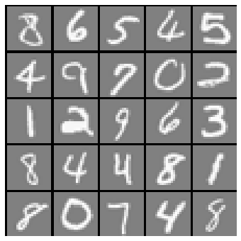

```python
# Display an example mosaic of our training images
display_data( X_train[:25, :])
```

Test the implementation of the training function

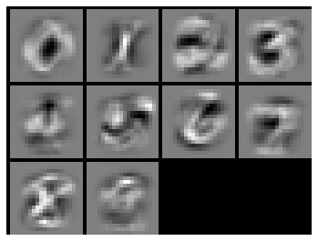

```python
lambda_val = 100
weight_vectors, intercepts = train_one_vs_all(X_train, y_train, 10, lambda_val)
display_data(weight_vectors.T) # display weight vectors as images
```

Make predictions using our predict function

```python
pred_train = predict_one_vs_all(X_train, weight_vectors, intercepts)
pred_test  = predict_one_vs_all(X_test,  weight_vectors, intercepts)

print("Training Set Accuracy: %f" % (np.mean(pred_train == y_train) * 100))
print("    Test Set Accuracy: %f" % (np.mean( pred_test == y_test) * 100))
```

```
Training Set Accuracy: 89.275000
    Test Set Accuracy: 88.300000
```

Below is an experiment with different values of lambda. Lambda is our regularization parameter that controls overfitting of the model.

```
0.001
```

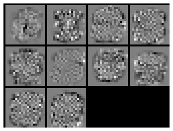

```
0.01
```

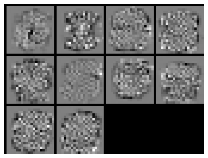

```
0.1
```

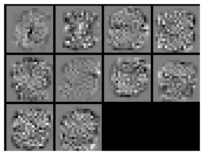

```
1.0
```

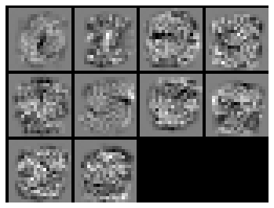

```
10.0
```

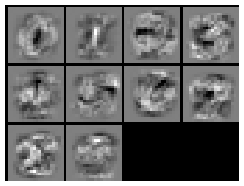

```
100.0
```

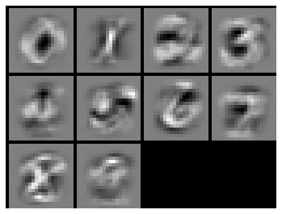

```
1000.0
```

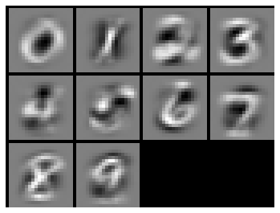

```
10000.0
```

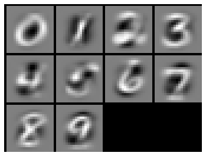

```
100000.0
```

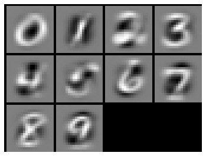

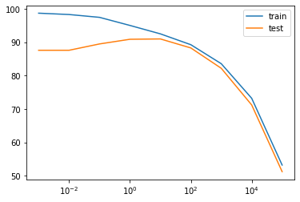

```python
from matplotlib.axes import SecondaryAxis
lambda_vals = 10**np.arange(-3., 6.)
num_classes = 10

train_acc = []
test_acc = []

for val in lambda_vals:
  weight_vectors, intercepts = train_one_vs_all(X_train, y_train, 10, val)
  print(val)
  display_data(weight_vectors.T)

  pred_train = predict_one_vs_all(X_train, weight_vectors, intercepts)
  pred_test  = predict_one_vs_all(X_test,  weight_vectors, intercepts)

  train_acc.append((np.mean(pred_train == y_train) * 100))
  test_acc.append((np.mean( pred_test == y_test) * 100))

# In your final plot, use these commands to provide a legend and set
# the horizontal axis to have a logarithmic scale so the value of lambda
# appear evenly spaced.
plt.plot(lambda_vals, train_acc)
plt.plot(lambda_vals, test_acc)
plt.legend(('train', 'test'))
plt.xscale('log')
```

Here we experiment with the learning curve of training our model. A learning curve shows accuracy on the vertical axis vs. the amount of training data used to learn the model on the horizontal axis.

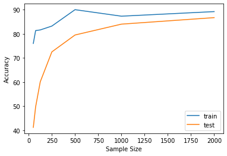

```python
m, n = X_train.shape

train_sizes = np.arange(250, 4000, 250)
nvals = len(train_sizes)

test_sizes = [50, 75, 125, 250, 500, 1000, 2000]

lambda_val = 100
train_acc = []
test_acc = []

for size in test_sizes:
  p = np.random.permutation(m)
  selected_examples = p[0:size]
  X_train_small = X_train[selected_examples,:]
  y_train_small = y_train[selected_examples]

  weight_vectors, intercepts = train_one_vs_all(X_train_small, y_train_small, 10, lambda_val)

  pred_train = predict_one_vs_all(X_train_small, weight_vectors, intercepts)
  pred_test  = predict_one_vs_all(X_test,  weight_vectors, intercepts)

  train_acc.append((np.mean(pred_train == y_train_small) * 100))
  test_acc.append((np.mean(pred_test == y_test) * 100))

plt.plot(test_sizes, train_acc)
plt.plot(test_sizes, test_acc)
plt.legend(('train', 'test'))
plt.ylabel("Accuracy")
plt.xlabel("Sample Size")
```

We see that the model reaches a point where accuracy starts to converge with the sample size. This allows us to select an optimal sample size that maximizes model accuracy and minimize the amount of time spent training the model.